# Corr-coeff

I want to investigate inference of population correlation coefficient(s) based the observed sample correlation coefficient(s).

Particularly I want to investigate how one might define a likelihood for an observed (sample) correlation coefficient, given some prior on the population correlation coefficient.

Let $\rho$ denote the population correlation coefficient and $r$ denote the observed sample correlation coefficient. Now define Fishers z-transform, $z(\rho)$ as follows:

```r
fisherz = function(r){
  return (0.5*log((1+r)/(1-r)))
}
```

Note that if the sample size is $n$ then $z(r)$ is approximately normal, with mean $z(\rho)$ and variance $1/(n-3)$. http://en.wikipedia.org/wiki/Fisher_transformation

So if $z:=z(r)$ is the observed value of $z$ then $p(z | \rho)$ is a simple normal distribution with mean $z(\rho)$.

I want to specify a prior on $\rho$ and integrate it out. The computations become analytic if I use a normal prior for $z(\rho)$, or indeed a mixture of normals. But I wanted to use a prior on $\rho$. For example, Guan and Stephens look at Uniform prior on the PVE in a multivariate regression, so here $PVE:=\rho^2$. The question here is how does a prior on $\rho$ transform to a prior on $z(\rho)$?

Let’s look for a Be(0.5,0.5) prior on the PVE.

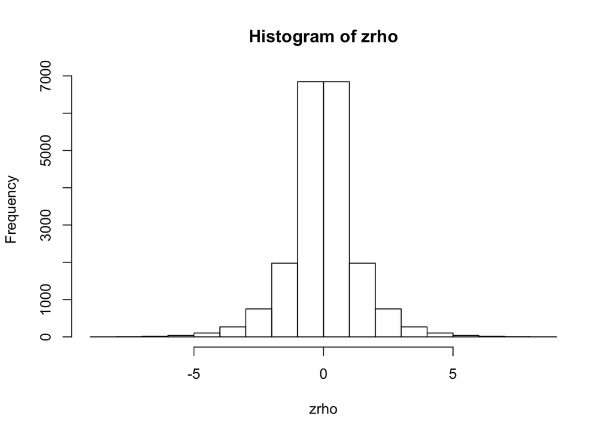

```r
  pve = rbeta(10000,0.5,0.5)
  rho = sqrt(pve)
  rho = c(-pve,pve) #make symetric about 0
  zrho = fisherz(rho)
  hist(zrho)
```

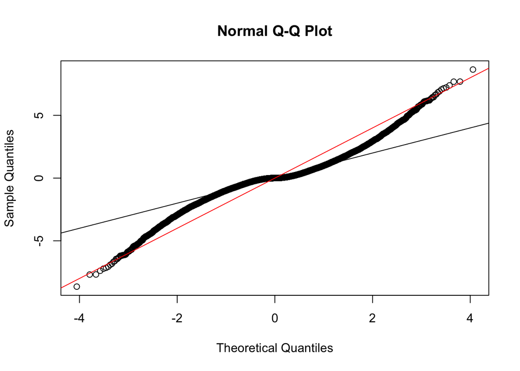

```r
  qqnorm(zrho)
  abline(a=0,b=1,col=1)
  abline(a=0,b=2,col=2)
```

Kind of looks like a mixture of normal distributions would fit. We can use ash to do this, setting se to be very small to reflect we don’t really have measurement error here.

```r
  library(ashr)
  ash(zrho,1e-6,mixsd = c(0,0.125,0.25,0.5,1,2,4),mixcompdist="normal",pointmass=FALSE,prior="uniform")
```

```
## $pi
## [1] 1.081556e-03 2.287052e-01 1.546454e-07 4.864325e-02 4.300486e-01
## [6] 2.820244e-01 9.496794e-03
##
## $mean
## [1] 0 0 0 0 0 0 0
##
## $sd
## [1] 0.000 0.125 0.250 0.500 1.000 2.000 4.000
##
## attr(,"row.names")
## [1] 1 2 3 4 5 6 7
## attr(,"class")
## [1] "normalmix"
```

```r
  fitnorm=function(alpha,beta){
    pve = rbeta(10000,alpha,beta)
    rho = sqrt(pve)
    rho = c(-pve,pve) #make symetric about 0
    zrho = fisherz(rho)
    ash(zrho,1e-6,mixsd = c(0,0.125,0.25,0.5,1,2,4),mixcompdist="normal",pointmass=FALSE,prior="uniform")
  }
  fit5=fitnorm(0.5,0.5)
  fit1=fitnorm(1,1)
```

It is kind of interesting that in the uniform case it seems to fit almost exactly $1/3 N(0,.5^2) + 2/3 N(0,1)$ for zrho.

We can use this to define a Bayes Factor:

```r
#' @param r observed correlation
#' @param n sample size
#' @param prior a mixture of normals prior for the fisher transform of rho (eg obtained from ash)
  BFrho = function(r,n,prior){
    zr = fisherz(r)
    s = sqrt(1/(n-3)) #standard error according to standard theory
    LH0 = dnorm(zr,0,s)
    g=prior
    g$sd = sqrt(g$sd^2 + s^2)  #gives standard deviation of observation, combining stanard error and prior
    LH1 = dens(g,zr)
    return(LH1/LH0)
  }
```

Let’s compare with http://www.ejwagenmakers.com/2012/WetzelsWagenmakers2012.pdf where they do the following example: ``Entering r=−.36 and n=54 in Eq. 13 yields a Bayes factor BF= 3.86, indicating that the data are 3.86 times more likely to have occurred under H1 than under H0“.

```r
  BFrho(0.36,54,fit1$fitted.g)
```

```
##          [,1]
## [1,] 5.650781
```

```r
  BFrho(0.36,54,fit5$fitted.g)
```

```
##          [,1]
## [1,] 3.994654
```